# Analysis of personal activity monitoring device data

## Introduction

It is now possible to collect a large amount of data about personal movement using activity monitoring devices such as a [Fitbit](http://www.fitbit.com), [Nike Fuelband](http://www.nike.com/us/en_us/c/nikeplus-fuelband), or [Jawbone Up](https://jawbone.com/up). These type of devices are part of the “quantified self” movement – a group of enthusiasts who take measurements about themselves regularly to improve their health, to find patterns in their behavior, or because they are tech geeks. But these data remain under-utilized both because the raw data are hard to obtain and there is a lack of statistical methods and software for processing and interpreting the data.

This assignment makes use of data from a personal activity monitoring device. This device collects data at 5 minute intervals through out the day. The data consists of two months of data from an anonymous individual collected during the months of October and November, 2012 and include the number of steps taken in 5 minute intervals each day.

## Data

The data for this assignment can be downloaded from the course web site:

- Dataset: [Activity monitoring data](https://d396qusza40orc.cloudfront.net/repdata%2Fdata%2Factivity.zip) [52K]

The variables included in this dataset are:

- **steps**: Number of steps taking in a 5-minute interval (missing values are coded as `NA`)
- **date**: The date on which the measurement was taken in YYYY-MM-DD format
- **interval**: Identifier for the 5-minute interval in which measurement was taken

The dataset is stored in a comma-separated-value (CSV) file and there are a total of 17,568 observations in this dataset.

## Assignment

### Loading and preprocessing the data

In the first step, we load the data into R environment from the CSV file in the working directory.

```r
# Read Activity monitoring data ('amd') data set from the working directory
amd <- read.csv("activity.csv", stringsAsFactors = FALSE)
head(amd)
```

```
##   steps       date interval
## 1    NA 2012-10-01        0
## 2    NA 2012-10-01        5
## 3    NA 2012-10-01       10
## 4    NA 2012-10-01       15
## 5    NA 2012-10-01       20
## 6    NA 2012-10-01       25
```

The data is in an appropriate form for further analysis. Thus, there is no need for further transformation.

### What is mean total number of steps taken per day?

We are interested in what is mean total number of steps taken per day. We begin with plotting a histogram of the total number of steps taken each day. Please note that for this part of the analysis, we ignore the missing values in the dataset.

- The histogram of the total number of steps of each day.

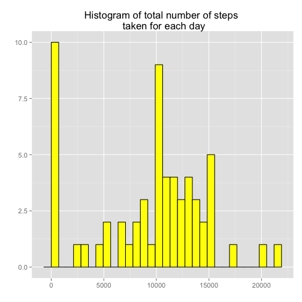

```r
# Group observations by date and sum steps taken per each day
library(dplyr)
total.steps.per.day <- amd %.% group_by(date) %.% summarise(total = sum(steps,
    na.rm = T))

library(ggplot2)
# Set default font size for all ggplot2 plots
theme_set(theme_gray(base_size = 14))

# The histogram display a general distribution of numbers which are total
# steps for each day in our data.
ggplot(total.steps.per.day, aes(x = total)) + geom_histogram(fill = "yellow",
    colour = "black")  + labs(title = "Histogram of total number of steps \n taken for each day") +
    labs(x = "", y = "")
```

- Calculate and report the mean and median total number of steps taken per day

```r
# Define total mean and total median of steps sums for each day
total.mean <- mean(total.steps.per.day$total)
print(total.mean)
```

```
## [1] 9354.23
```

```r
total.median <- median(total.steps.per.day$total)
print(total.median)
```

```
## [1] 10395
```

### What is the average daily activity pattern?

- We investigate the daily activity pattern by observing the average number of steps taken for subsequent day 5-minute intervals, averaged across all days. This pattern is presented on the plot below.

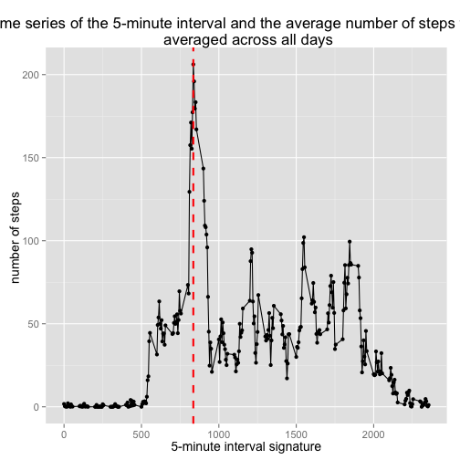

```r
# Create data frame with number of steps taken, averaged across all days
avg.intvl.steps <- amd %.% group_by(interval) %.% summarise(avg.intvl = mean(steps,
    na.rm = T))

# Find out which 5-minute interval contains the maximum number of steps
max.num.of.steps.interv.ind <- which(avg.intvl.steps$avg.intvl == max(avg.intvl.steps$avg.intvl))
max.num.of.steps.interv <- avg.intvl.steps[max.num.of.steps.interv.ind, 1]

qplot(interval, avg.intvl, data = avg.intvl.steps) + geom_line() + geom_vline(xintercept = max.num.of.steps.interv,
    color = "red", linetype = "dashed", size = 1) + labs(title = "Time series of the 5-minute interval and the average number of steps taken, \n averaged across all days") +
    labs(x = "5-minute interval signature", y = "number of steps ")
```

#### 5-minute interval with the maximum number of steps

On the plot there is a red line representing the maximum of averaged number of steps per each 5-minute time interval. The maximum is found in the interwal with signature: 835.

Signature 835 represents time of some early part of a day. It seems sensible as we realize that during early day hours people generaly tend to get up; they are supposed to be in a rush waking up and going to school / work etc., making plenty of meters / kilometers by foot.

### Imputing mission values

#### Total number of mission value in the dataset

```r
na.rows.num <- nrow(amd) - sum(complete.cases(amd))
na.rows.num
```

```
## [1] 2304
```

#### A strategy for filling in all of the missing values in the dataset

```r
# Create copy of a base data frame
amd.na.imputed <- amd

for (row.num in 1:nrow(amd.na.imputed)) {

    if (is.na(amd.na.imputed[row.num, "steps"])) {

        interval.sgn <- amd.na.imputed[row.num, "interval"]
        interval.sgn.ind <- which(avg.intvl.steps[, "interval"] == interval.sgn)
        interval.steps.mean <- avg.intvl.steps[interval.sgn.ind, "avg.intvl"]
        amd.na.imputed[row.num, "steps"] <- interval.steps.mean
        message(paste0("NA value in row num. ", row.num, " imputed!"))
    }
}
```

```r
# Check if number of complete cases equals number of rows
(nrow(amd.na.imputed) - sum(complete.cases(amd.na.imputed))) == 0
```

```
## [1] TRUE
```

#### Dataset with imputed NA values - histogram of the total number of steps taken each day

Now we can plot histogram of the total number of steps taken each day with imputed NA values

```r
total.steps.per.day.imputed <- amd.na.imputed %.% group_by(date) %.% summarise(total = sum(steps,
    na.rm = T))

total.mean.imputed <- mean(total.steps.per.day.imputed$total)
print(total.mean.imputed)
```

```
## [1] 10766.19
```

```r
total.median.imputed <- median(total.steps.per.day.imputed$total)
print(total.median.imputed)
```

```
## [1] 10766.19
```

```
## stat_bin: binwidth defaulted to range/30. Use 'binwidth = x' to adjust this.
```

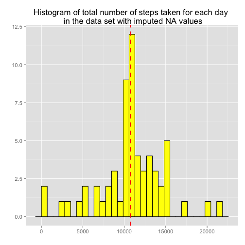

```r
# The histogram display a general distribution of numbers
# which are total steps for each day in our data.

ggplot(total.steps.per.day.imputed, aes(x = total)) + geom_histogram(fill = "yellow",
    colour = "black") + geom_vline(xintercept = total.mean.imputed, color = "brown",
    linetype = "dashed", size = 1) + geom_vline(xintercept = total.median.imputed,
    color = "red", linetype = "dashed", size = 1) + labs(title = "Histogram of total number of steps taken for each day \n in the data set with imputed NA values") +
    labs(x = "", y = "")
```

#### Dataset with imputed NA values - the mean and median total number of steps taken per day

We can observe that imputing NA values does have an inpact on total number of steps taken per day values:

- both mean and median are higher than the same metrics taken from the raw data,
- suprisingly, mean and median have exactly the same values this time; they both equal 1.0766 × 104 (this value is marked on the histogram with the use of a red vertical line).

Sorry for no enough time to finish.